# Project Introduction

The objective of this project is to wrangle and analyze several datasets of weratedogs twitter page data, This would happen through five stages:

- Gathering the data from three different resources
- Assessing the data quality and tideness
- Cleaning it
- Storing the cleaned data
- Performing different analysis and coming with outputs

#### Customers activity over the time

- Highest numbers of favorites came in 2017-7
- Highest numbers of retweets came in 2015-12
- Lowest numbers of favorites came in 2016-4
- Lowest numbers of retweets came in 2016-4
- The page had a huge traffic in 2015-12 and then dropped and came back again in 2017
- It seems like traffic increases in Summer(June and July) and new year holiday in December
- There is a positive correlation between favorites and retweets over the time, yet not always, (example is 2017-7, high number of favorites but slight increase in retweets)

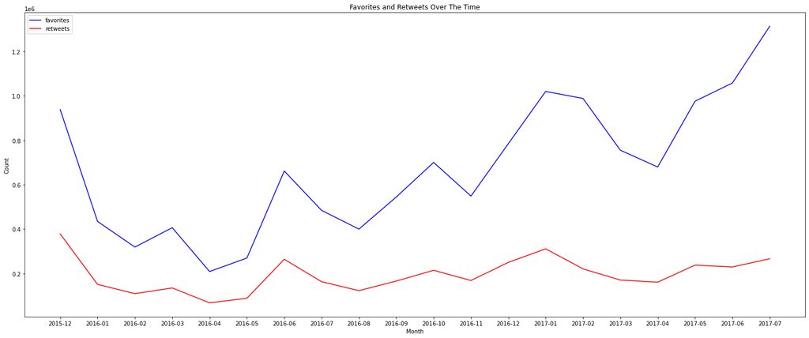

#### The most common dog breed for each dog type tweeted

- golden retriever is the most common pupper
- golden retriever is the most common doggo
- Eskimo_dog, golden_retriever and Labrador_retriever are the most common puppo
- Samoyed is the most common floofer

#### The highest and lowest tweeted dog types

- Pupper is the most common dog type in tweets
- Floofer is the least common dog type in tweets

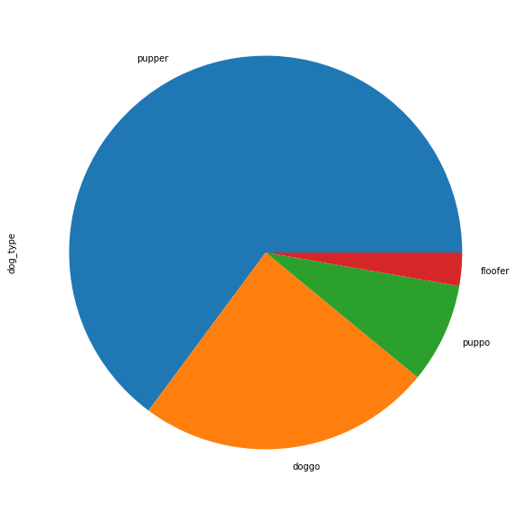

#### The highest and lowest tweeted dog breeds

- Golden Retriever is the most common dog breed in tweets
- clumber is the least common dog breed in tweets

##### And that's an image explaining why Golden retriever is the most common

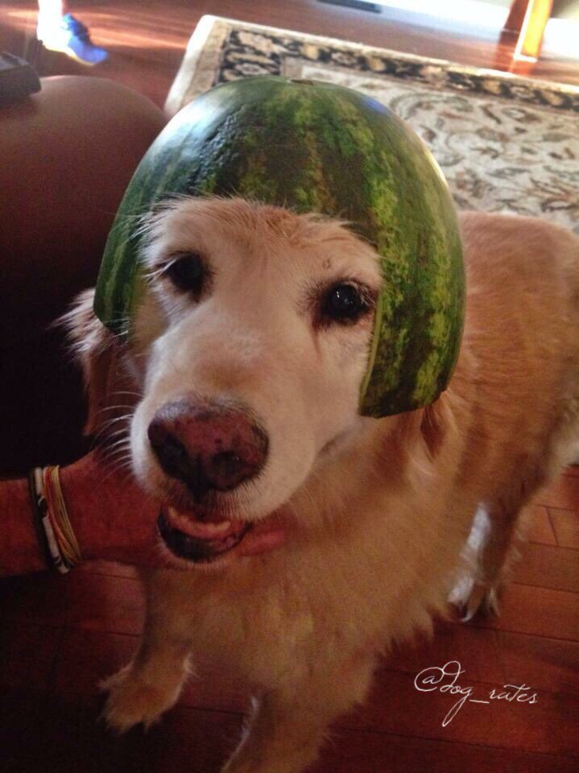

##### And here's an image of a clumber

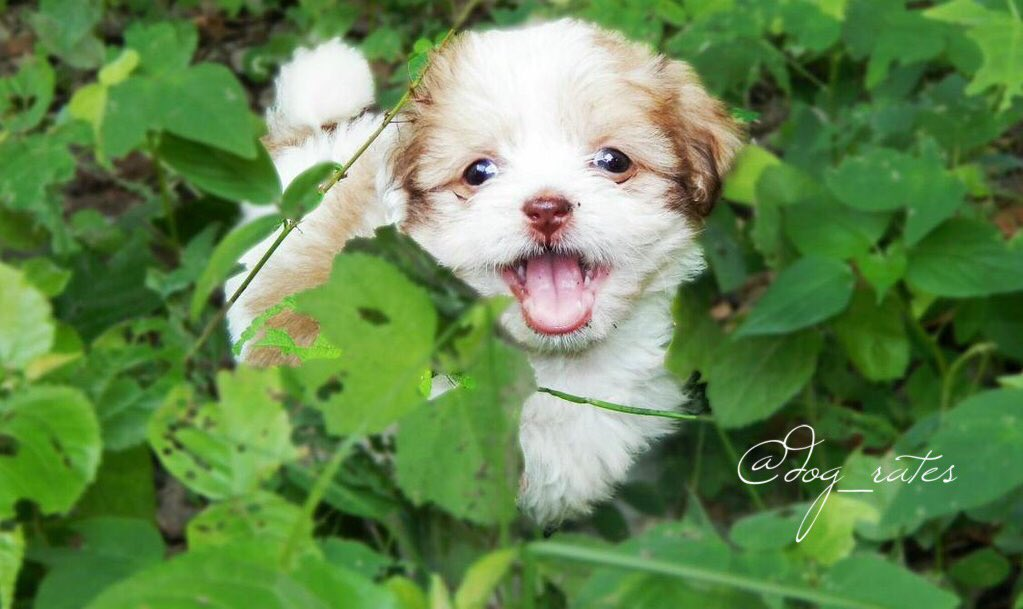

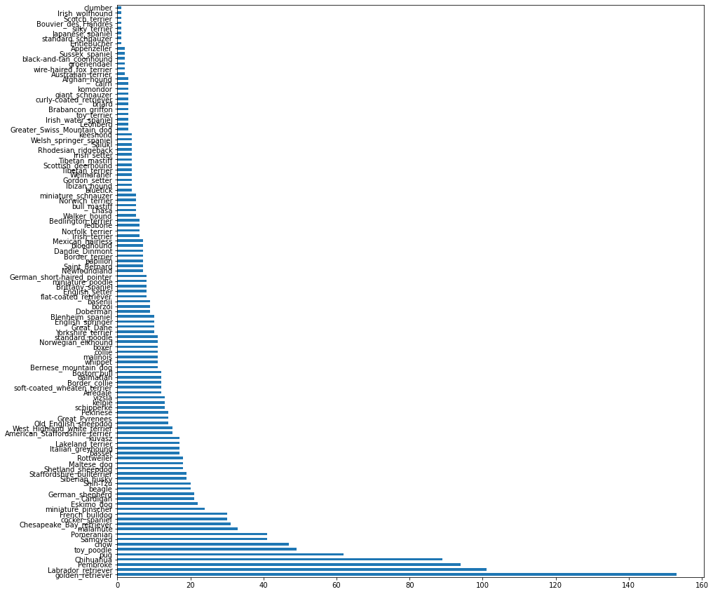

#### The highest and lowest favorites and retweets dog types

- While pupper is the most common dog type, doggo is the most retweeted and favored

#### The highest and lowest favorites and retweets dog breeds

- Golden retriever is not just the most common dog breed but it's also the most retweeted and favored

#### Followers count over time

- It seems like the followers count is stagnant over the three years, as the minimum and maximum count of followers over the time is very similar, I'd say there's something wrong with these data as it's quite unrealistic

# Analysis Journey

### The conclusion out of this is it's very fun to do the analysis after some hard time making the data ready, here we got several insights of a huge amount of data simply

### What we did in this project can be apply to lots of different sites, pages or others, by using these analysis smartly any one can grow and develop what he/she is working on.